# DATA624-HW4-Preprocessing

Kuhn & Johnson exercises 3.1, 3.2

Michael Y.

3/1/2020

```r
library(fpp2)
library(tidyverse)
```

```r
library(corrplot)
library(e1071)
library(caret)
library(kableExtra)
library(AppliedPredictiveModeling)
```

# Homework 4 - Preprocessing

Do problems 3.1 and 3.2 in the Kuhn and Johnson book Applied Predictive Modeling. Please submit both your Rpubs link as well as attach the .rmd file with your code.

## 3.1 Glass identification

The UC Irvine Machine Learning Repository6 contains a data set related to glass identification.  
The data consist of 214 glass samples labeled as one of seven class categories.  
There are nine predictors, including

- the refractive index (“RI”) and
- percentages of eight elements:
  - Na, Mg, Al, Si, K, Ca, Ba, and Fe.

The data can be accessed via:

```r
library(mlbench)
data(Glass)
str(Glass)
```

```
## 'data.frame':    214 obs. of  10 variables:
##  $ RI  : num  1.52 1.52 1.52 1.52 1.52 ...
##  $ Na  : num  13.6 13.9 13.5 13.2 13.3 ...
##  $ Mg  : num  4.49 3.6 3.55 3.69 3.62 3.61 3.6 3.61 3.58 3.6 ...
##  $ Al  : num  1.1 1.36 1.54 1.29 1.24 1.62 1.14 1.05 1.37 1.36 ...
##  $ Si  : num  71.8 72.7 73 72.6 73.1 ...
##  $ K   : num  0.06 0.48 0.39 0.57 0.55 0.64 0.58 0.57 0.56 0.57 ...
##  $ Ca  : num  8.75 7.83 7.78 8.22 8.07 8.07 8.17 8.24 8.3 8.4 ...
##  $ Ba  : num  0 0 0 0 0 0 0 0 0 0 ...
##  $ Fe  : num  0 0 0 0 0 0.26 0 0 0 0.11 ...
##  $ Type: Factor w/ 6 levels "1","2","3","5",..: 1 1 1 1 1 1 1 1 1 1 ...
```

```r
#'data.frame': 214 obs. of 10 variables:
#$ RI : num 1.52 1.52 1.52 1.52 1.52 ...
#$ Na : num 13.6 13.9 13.5 13.2 13.3 ...
#$ Mg : num 4.49 3.6 3.55 3.69 3.62 3.61 3.6 3.61 3.58 3.6 ...
#$ Al : num 1.1 1.36 1.54 1.29 1.24 1.62 1.14 1.05 1.37 1.36 ...
#$ Si : num 71.8 72.7 73 72.6 73.1 ...
#$ K : num 0.06 0.48 0.39 0.57 0.55 0.64 0.58 0.57 0.56 0.57 ...
#$ Ca : num 8.75 7.83 7.78 8.22 8.07 8.07 8.17 8.24 8.3 8.4 ...
#$ Ba : num 0 0 0 0 0 0 0 0 0 0 ...
#$ Fe : num 0 0 0 0 0 0.26 0 0 0 0.11 ...
#$ Type: Factor w/ 6 levels "1","2","3","5",..: 1 1 1 1 1 1 1 1 1 1 ...
```

### (a) Using visualizations, explore the predictor variables to understand their distributions as well as the relationships between predictors.

```r
Glass %>%
  select (-Type) -> Glass_Predictors
```

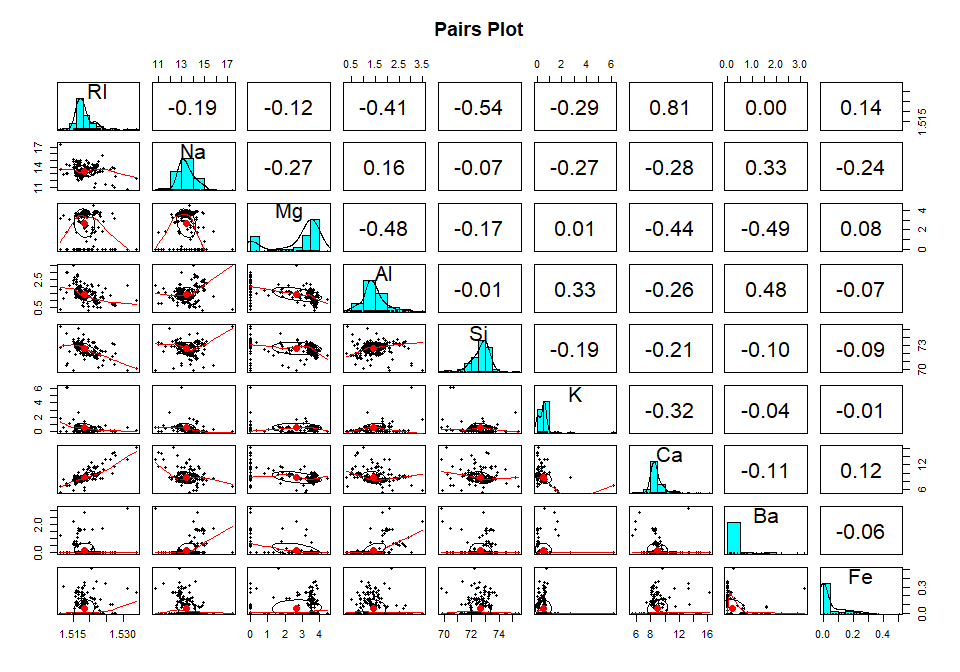

```r
#### Pairs plot
psych::pairs.panels(Glass_Predictors, main="Pairs Plot")
```

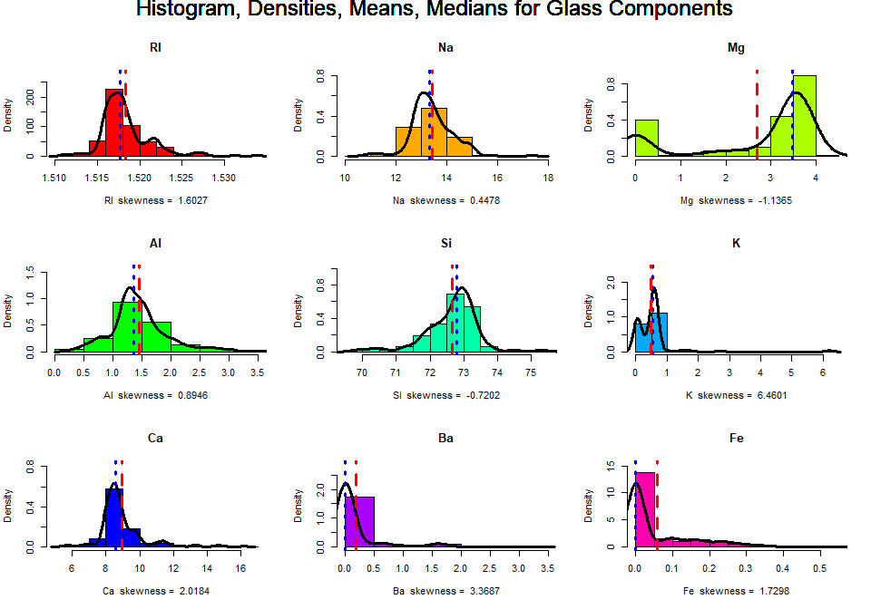

```r
#### Histogram and Density
par(mfrow=c(3,3),oma= c(0, 0, 2, 0))
for (col in 1:ncol(Glass_Predictors)) {
    hist(Glass_Predictors[,col],
         col=rainbow(9)[col],
         prob=TRUE,
         main=names(Glass_Predictors[col]),
         xlab=paste(names(Glass_Predictors[col])," skewness = ",
                    round(skewness(Glass_Predictors[,col]),4)),
         ylim=c(0,1.3*max(density(Glass_Predictors[,col])$y))
         )
    lines(density(Glass_Predictors[,col]),lwd=3)
    abline(v=median(Glass_Predictors[,col]),lwd=3,lty=3, col="blue")
    abline(v=mean(Glass_Predictors[,col]),lwd=3,lty=2, col="red")
mtext("Histogram, Densities, Means, Medians for Glass Components",
      side = 3, line = +0.5, outer = TRUE, cex=1.5)

}
```

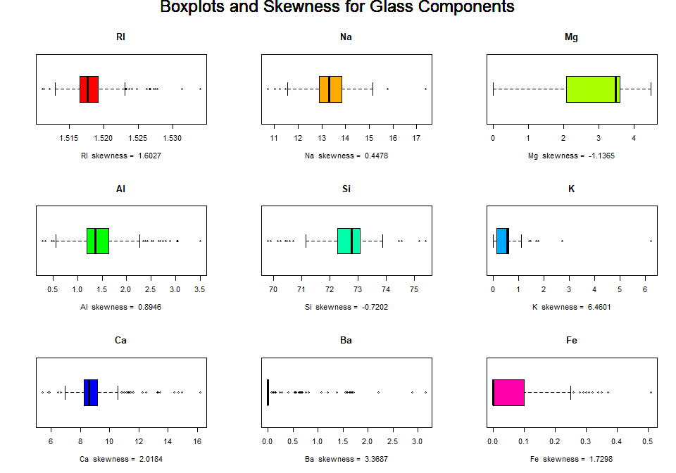

```r
#### Boxplots
par(mfrow=c(3,3),oma= c(0, 0, 2, 0))
for (col in 1:ncol(Glass_Predictors)) {
    boxplot(Glass_Predictors[,col],
         col=rainbow(9)[col],
         horizontal = TRUE,
         main=names(Glass_Predictors[col]),
         xlab=paste(names(Glass_Predictors[col])," skewness = ",
                    round(skewness(Glass_Predictors[,col]),4))
         )

mtext("Boxplots and Skewness for Glass Components",
      side = 3, line = +0.5, outer = TRUE, cex=1.5)

}
```

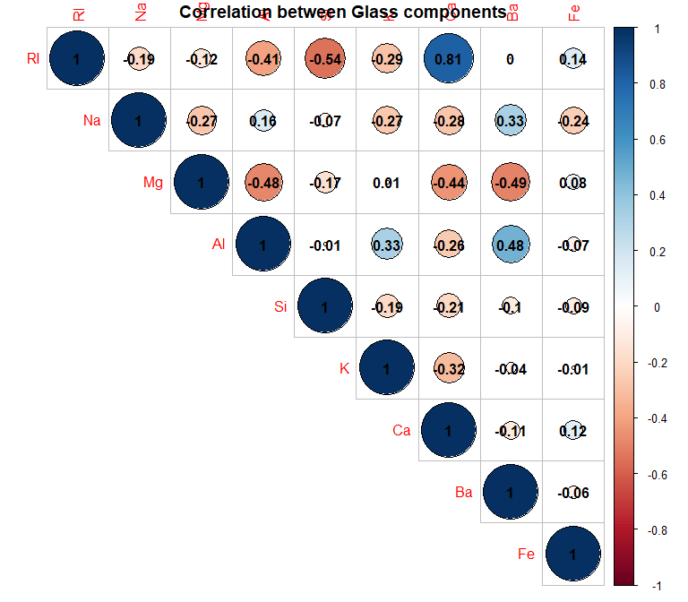

```r
#### Correlations
GlassCorr <- cor(Glass_Predictors)

corrplot(corr = GlassCorr, type = "upper", outline = T, order="original",
           sig.level = 0.05, insig = "blank", addCoef.col = "black",
           title = "\nCorrelation between Glass components",
           number.cex = 1.0, number.font = 2, number.digits = 2 )
```

There is a very high positive correlation, +.81, between `Ca` and the Refractive Index, `RI`.  
There are a number of moderately strong correlations, both positive and negative, with values close to $\pm 0.5$.

### (b) Do there appear to be any outliers in the data? Are any predictors skewed?

```r
# Skewness
apply(X = Glass_Predictors, MARGIN = 2, FUN=skewness) %>% sort -> Glass_Skew
Glass_Skew %>%
  kable(caption = "Skewness") %>%
  kable_styling(c("bordered","striped"),full_width = F)
```

Skewness

|  | x |
| --- | --- |
| Mg | -1.1364523 |
| Si | -0.7202392 |
| Na | 0.4478343 |
| Al | 0.8946104 |
| RI | 1.6027151 |
| Fe | 1.7298107 |
| Ca | 2.0184463 |
| Ba | 3.3686800 |
| K | 6.4600889 |

The boxplots reveal numerous outliers, most notably with **K**.  
Because most of the values for **Ba** (176) and **Fw** (144) are zeroes, all the other points for these elements appear as “outliers” under the standard boxplot method.

**Mg** is heavily skewed to the **left**.  
**K, Ba, Ca**, and **Fe** are heavily skewed to the **right**.  
**RI** and **Al** are mildly skewed to the **right**.

### (c) Are there any relevant transformations of one or more predictors that might improve the classification model?

We’ll try the following set of transformations:

- Box-Cox transformation
- Center the variables at mean=0
- Scale to stdev=1

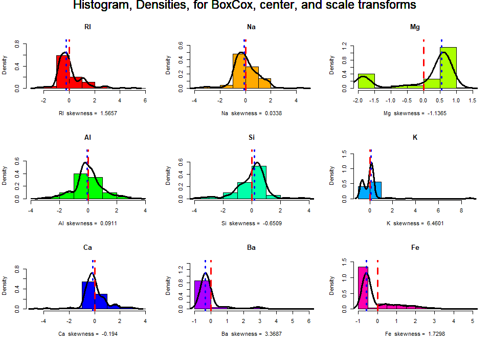

```r
Glass_BoxCox1 <- predict(preProcess(Glass_Predictors,
                                    method=c('BoxCox','center','scale')),
                         Glass_Predictors)

par(mfrow=c(3,3),oma= c(0, 0, 2, 0))
for (col in 1:ncol(Glass_BoxCox1)) {
    hist(Glass_BoxCox1[,col],
         col=rainbow(9)[col],
         prob=TRUE,
         main=names(Glass_BoxCox1[col]),
         xlab=paste(names(Glass_BoxCox1[col])," skewness = ",
                    round(skewness(Glass_BoxCox1[,col]),4)),
         ylim=c(0,1.3*max(density(Glass_BoxCox1[,col])$y))
         )
    lines(density(Glass_BoxCox1[,col]),lwd=3)
    abline(v=median(Glass_BoxCox1[,col]),lwd=3,lty=3, col="blue")
    abline(v=mean(Glass_BoxCox1[,col]),lwd=3,lty=2, col="red")
mtext("Histogram, Densities, for BoxCox, center, and scale transforms",
      side = 3, line = +0.5, outer = TRUE, cex=1.5)
}
```

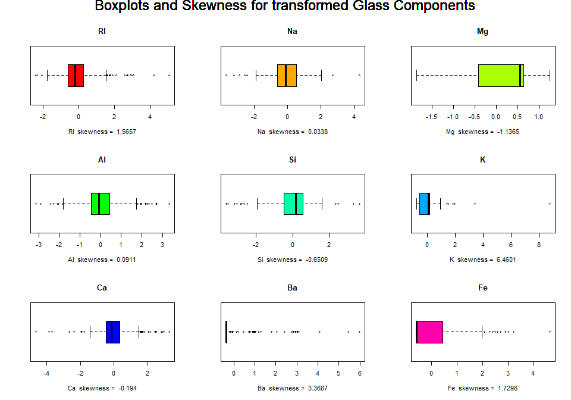

```r
#### Boxplots following transformations
par(mfrow=c(3,3),oma= c(0, 0, 2, 0))
for (col in 1:ncol(Glass_BoxCox1)) {
    boxplot(Glass_BoxCox1[,col],
         col=rainbow(9)[col],
         horizontal = TRUE,
         main=names(Glass_BoxCox1[col]),
         xlab=paste(names(Glass_BoxCox1[col])," skewness = ",
                    round(skewness(Glass_BoxCox1[,col]),4))
         )

mtext("Boxplots and Skewness for transformed Glass Components",
      side = 3, line = +0.5, outer = TRUE, cex=1.5)

}
```

The variables are now all standardized with a centered mean=0 and stdev=1. The Box-Cox transformation does not impact most of these variables.  
It does improve the following items:

- **Na**, for which the skewness has reduced from 0.4478 to 0.0338
- **Al**, for which the skewness has reduced from 0.8946 to 0.0911
- **Ca**, for which the skewness has reduced from 2.0184 to -0.194

The Box-Cox transformation doesn’t have an appreciable improvement on the skewness of the other variables.

#### Skewness before and after Box-Cox transformation

```r
rbind(orig=apply(X = Glass_Predictors, MARGIN = 2, FUN=skewness),
      xformed=apply(X = Glass_BoxCox1, MARGIN = 2, FUN=skewness)) %>%
  kable(caption = "Skewness, before and after transformation")%>%
    kable_styling(c("bordered","striped"))
```

Skewness, before and after transformation

|  | RI | Na | Mg | Al | Si | K | Ca | Ba | Fe |
| --- | --- | --- | --- | --- | --- | --- | --- | --- | --- |
| orig | 1.602715 | 0.4478343 | -1.136452 | 0.8946104 | -0.7202392 | 6.460089 | 2.0184463 | 3.36868 | 1.729811 |
| xformed | 1.565660 | 0.0338464 | -1.136452 | 0.0910590 | -0.6509057 | 6.460089 | -0.1939557 | 3.36868 | 1.729811 |

## 3.2 Diseased Soybeans

The soybean data can also be found at the UC Irvine Machine Learning Repository.  
Data were collected to predict disease in 683 soybeans.  
The 35 predictors are mostly categorical and include information on the environmental conditions (e.g., temperature, precipitation) and plant conditions (e.g., left spots, mold growth).  
The outcome labels consist of 19 distinct classes.

The data can be loaded via:

```r
library(mlbench)
data(Soybean)
##See ?Soybean for details
```

**Description**

There are 19 classes, only the first 15 of which have been used in prior work.  
The folklore seems to be that the last four classes are unjustified by the data since they have so few examples.  
There are 35 categorical attributes, some nominal and some ordered.  
The value “dna” means does not apply.  
The values for attributes are encoded numerically, with the first value encoded as “0,” the second as “1,” and so forth.

**Format**

A data frame with 683 observations on 36 variables.  
There are 35 categorical attributes, all numerical and a nominal denoting the class.

[,1] `Class` the 19 classes  
[,2] `date` apr(0),may(1),june(2),july(3),aug(4),sept(5),oct(6).  
[,3] `plant.stand` normal(0),lt-normal(1).  
[,4] `precip` lt-norm(0),norm(1),gt-norm(2).  
[,5] `temp` lt-norm(0),norm(1),gt-norm(2).  
[,6] `hail` yes(0),no(1).  
[,7] `crop.hist` dif-lst-yr(0),s-l-y(1),s-l-2-y(2), s-l-7-y(3).  
[,8] `area.dam` scatter(0),low-area(1),upper-ar(2),whole-field(3).  
[,9] `sever` minor(0),pot-severe(1),severe(2).  
[,10] `seed.tmt` none(0),fungicide(1),other(2).  
[,11] `germ` 90-100%(0),80-89%(1),lt-80%(2).  
[,12] `plant.growth` norm(0),abnorm(1).  
[,13] `leaves` norm(0),abnorm(1).  
[,14] `leaf.halo` absent(0),yellow-halos(1),no-yellow-halos(2).  
[,15] `leaf.marg` w-s-marg(0),no-w-s-marg(1),dna(2).  
[,16] `leaf.size` lt-1/8(0),gt-1/8(1),dna(2).  
[,17] `leaf.shread` absent(0),present(1).  
[,18] `leaf.malf` absent(0),present(1).  
[,19] `leaf.mild` absent(0),upper-surf(1),lower-surf(2).  
[,20] `stem` norm(0),abnorm(1).  
[,21] ``lodging` yes(0),no(1).  
[,22] `stem.cankers` absent(0),below-soil(1),above-s(2),ab-sec-nde(3).  
[,23] `canker.lesion` dna(0),brown(1),dk-brown-blk(2),tan(3).  
[,24] `fruiting.bodies` absent(0),present(1).  
[,25] `ext.decay` absent(0),firm-and-dry(1),watery(2).  
[,26] `mycelium` absent(0),present(1).  
[,27] `int.discolor` none(0),brown(1),black(2).  
[,28] `sclerotia` absent(0),present(1).  
[,29] `fruit.pods` norm(0),diseased(1),few-present(2),dna(3).  
[,30] `fruit.spots` absent(0),col(1),br-w/blk-speck(2),distort(3),dna(4).  
[,31] `seed` norm(0),abnorm(1).  
[,32] `mold.growth` absent(0),present(1).  
[,33] `seed.discolor` absent(0),present(1).  
[,34] `seed.size` norm(0),lt-norm(1).  
[,35] `shriveling` absent(0),present(1).  
[,36] `roots` norm(0),rotted(1),galls-cysts(2).

### (a) Investigate the frequency distributions for the categorical predictors.

```r
### Summary
summary(Soybean)
```

```
##                  Class          date     plant.stand  precip      temp
##  brown-spot         : 92   5      :149   0   :354    0   : 74   0   : 80
##  alternarialeaf-spot: 91   4      :131   1   :293    1   :112   1   :374
##  frog-eye-leaf-spot : 91   3      :118   NA's: 36    2   :459   2   :199
##  phytophthora-rot   : 88   2      : 93               NA's: 38   NA's: 30
##  anthracnose        : 44   6      : 90
##  brown-stem-rot     : 44   (Other):101
##  (Other)            :233   NA's   :  1
##    hail     crop.hist  area.dam    sever     seed.tmt     germ     plant.growth
##  0   :435   0   : 65   0   :123   0   :195   0   :305   0   :165   0   :441
##  1   :127   1   :165   1   :227   1   :322   1   :222   1   :213   1   :226
##  NA's:121   2   :219   2   :145   2   : 45   2   : 35   2   :193   NA's: 16
##             3   :218   3   :187   NA's:121   NA's:121   NA's:112
##             NA's: 16   NA's:  1
##
##
##  leaves  leaf.halo  leaf.marg  leaf.size  leaf.shread leaf.malf  leaf.mild
##  0: 77   0   :221   0   :357   0   : 51   0   :487    0   :554   0   :535
##  1:606   1   : 36   1   : 21   1   :327   1   : 96    1   : 45   1   : 20
##          2   :342   2   :221   2   :221   NA's:100    NA's: 84   2   : 20
##          NA's: 84   NA's: 84   NA's: 84                          NA's:108
##
##
##
##    stem     lodging    stem.cankers canker.lesion fruiting.bodies ext.decay
##  0   :296   0   :520   0   :379     0   :320      0   :473        0   :497
##  1   :371   1   : 42   1   : 39     1   : 83      1   :104        1   :135
##  NA's: 16   NA's:121   2   : 36     2   :177      NA's:106        2   : 13
##                        3   :191     3   : 65                      NA's: 38
##                        NA's: 38     NA's: 38
##
##
##  mycelium   int.discolor sclerotia  fruit.pods fruit.spots   seed
##  0   :639   0   :581     0   :625   0   :407   0   :345    0   :476
##  1   :  6   1   : 44     1   : 20   1   :130   1   : 75    1   :115
##  NA's: 38   2   : 20     NA's: 38   2   : 14   2   : 57    NA's: 92
##             NA's: 38                3   : 48   4   :100
##                                     NA's: 84   NA's:106
##
##
##  mold.growth seed.discolor seed.size  shriveling  roots
##  0   :524    0   :513      0   :532   0   :539   0   :551
##  1   : 67    1   : 64      1   : 59   1   : 38   1   : 86
##  NA's: 92    NA's:106      NA's: 92   NA's:106   2   : 15
##                                                  NA's: 31
##
##
##
```

```r
n = ncol(Soybean)
```

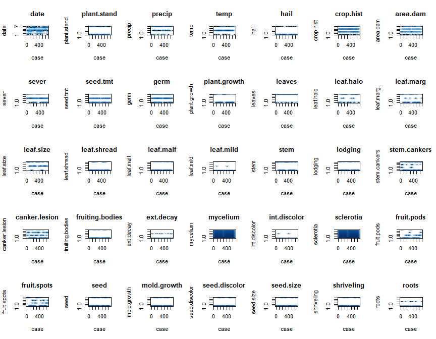

```r
SoybeanPred <- Soybean[,-1]
### Scatterplots
par(mfrow = c(5,7))
for (i in 1:ncol(SoybeanPred)) {
  smoothScatter(SoybeanPred[ ,i],
                xlab="case",
                ylab =names(SoybeanPred[i]),
                main = names(SoybeanPred[i]))
}
```

```r
ratio = NULL
tabl = list()
sumtabl = list()
for (i in colnames(Soybean)) {
  print("_______________________________________________________________________________")
  print(i);
  tabl[[i]] = sort(table(Soybean[,i]),decreasing = T)
  sumtabl[[i]] = sum(tabl[[i]])
  result=tabl[[i]] / sumtabl[[i]]
  print(result)
    ratio[i] = result[1]/result[2]
  print(paste("ratio of first 2 values in ",i,": ", round(ratio[i],4)))
}
```

```
## [1] "_______________________________________________________________________________"
## [1] "Class"
##
##                  brown-spot         alternarialeaf-spot
##                  0.13469985                  0.13323572
##          frog-eye-leaf-spot            phytophthora-rot
##                  0.13323572                  0.12884334
##                 anthracnose              brown-stem-rot
##                  0.06442167                  0.06442167
##            bacterial-blight           bacterial-pustule
##                  0.02928258                  0.02928258
##                charcoal-rot       diaporthe-stem-canker
##                  0.02928258                  0.02928258
##                downy-mildew      phyllosticta-leaf-spot
##                  0.02928258                  0.02928258
##              powdery-mildew           purple-seed-stain
##                  0.02928258                  0.02928258
##        rhizoctonia-root-rot                2-4-d-injury
##                  0.02928258                  0.02342606
## diaporthe-pod-&-stem-blight               cyst-nematode
##                  0.02196193                  0.02049780
##            herbicide-injury
##                  0.01171303
## [1] "ratio of first 2 values in  Class :  1.011"
## [1] "_______________________________________________________________________________"
## [1] "date"
##
##          5          4          3          2          6          1          0
## 0.21847507 0.19208211 0.17302053 0.13636364 0.13196481 0.10997067 0.03812317
## [1] "ratio of first 2 values in  date :  1.1374"
## [1] "_______________________________________________________________________________"
## [1] "plant.stand"
##
##         0         1
## 0.5471406 0.4528594
## [1] "ratio of first 2 values in  plant.stand :  1.2082"
## [1] "_______________________________________________________________________________"
## [1] "precip"
##
##         2         1         0
```

[output cut: 179 more lines]

```
##         0         1
## 0.9001692 0.0998308
## [1] "ratio of first 2 values in  seed.size :  9.0169"
## [1] "_______________________________________________________________________________"
## [1] "shriveling"
##
##          0          1
## 0.93414211 0.06585789
## [1] "ratio of first 2 values in  shriveling :  14.1842"
## [1] "_______________________________________________________________________________"
## [1] "roots"
##
##          0          1          2
## 0.84509202 0.13190184 0.02300613
## [1] "ratio of first 2 values in  roots :  6.407"
```

#### Variance of each predictor

```r
# compute the variance on each column (excluding the first column, Class), ignoring NAs
apply(X=Soybean[,2:36],MARGIN = 2, FUN=var, na.rm=T) %>%
  sort() %>%
  kable(caption="Variance of each predictor") %>%
  kable_styling(c("bordered","striped"),full_width = F)
```

Variance of each predictor

|  | x |
| --- | --- |
| mycelium | 0.0092301 |
| sclerotia | 0.0300929 |
| shriveling | 0.0616274 |
| lodging | 0.0692713 |
| leaf.malf | 0.0695976 |
| seed.size | 0.0900169 |
| seed.discolor | 0.0987868 |
| leaves | 0.1001748 |
| mold.growth | 0.1006854 |
| leaf.shread | 0.1377871 |
| fruiting.bodies | 0.1480117 |
| seed | 0.1569876 |
| leaf.mild | 0.1633086 |
| hail | 0.1752241 |
| int.discolor | 0.1755597 |
| roots | 0.1925683 |
| plant.growth | 0.2243608 |
| ext.decay | 0.2279696 |
| stem | 0.2472097 |
| plant.stand | 0.2481613 |
| sever | 0.3564428 |
| leaf.size | 0.3741688 |
| seed.tmt | 0.3748390 |
| temp | 0.3946533 |
| precip | 0.4707978 |
| germ | 0.6256614 |
| fruit.pods | 0.7788287 |
| leaf.halo | 0.9005980 |
| leaf.marg | 0.9149195 |
| crop.hist | 0.9521185 |
| area.dam | 1.1542798 |
| canker.lesion | 1.1750590 |
| stem.cankers | 1.8270836 |
| fruit.spots | 2.2599834 |
| date | 2.8700333 |

#### Are any of the distributions degenerate in the ways discussed earlier in this chapter?

Here are the definitions from the book:

##### **zero variance predictor**: a predictor variable that has a single unique value

There are no such variables with zero variance.

##### **near-zero** variance predictors:

- may have a single value for the vast majority of the samples;
- some predictors might have only a handful of unique values that occur with very low frequencies

##### Rule-of-thumb:

###### The fraction of unique values over the sample size is low (say 10%).

All variables meet this criterion.

###### The ratio of the frequency of the most prevalent value to the frequency of the second most prevalent value is large (say around 20).

The following variables meet this criterion:

- leaf.mild
- mycelium
- sclerotia

There is a function, `caret::nearZeroVar` , which can compute this directly:

```r
caret::nearZeroVar(Soybean[,2:36],names=T,saveMetrics = T)
```

```
##                  freqRatio percentUnique zeroVar   nzv
## date              1.137405     1.0248902   FALSE FALSE
## plant.stand       1.208191     0.2928258   FALSE FALSE
## precip            4.098214     0.4392387   FALSE FALSE
## temp              1.879397     0.4392387   FALSE FALSE
## hail              3.425197     0.2928258   FALSE FALSE
## crop.hist         1.004587     0.5856515   FALSE FALSE
## area.dam          1.213904     0.5856515   FALSE FALSE
## sever             1.651282     0.4392387   FALSE FALSE
## seed.tmt          1.373874     0.4392387   FALSE FALSE
## germ              1.103627     0.4392387   FALSE FALSE
## plant.growth      1.951327     0.2928258   FALSE FALSE
## leaves            7.870130     0.2928258   FALSE FALSE
## leaf.halo         1.547511     0.4392387   FALSE FALSE
## leaf.marg         1.615385     0.4392387   FALSE FALSE
## leaf.size         1.479638     0.4392387   FALSE FALSE
## leaf.shread       5.072917     0.2928258   FALSE FALSE
## leaf.malf        12.311111     0.2928258   FALSE FALSE
## leaf.mild        26.750000     0.4392387   FALSE  TRUE
## stem              1.253378     0.2928258   FALSE FALSE
## lodging          12.380952     0.2928258   FALSE FALSE
## stem.cankers      1.984293     0.5856515   FALSE FALSE
## canker.lesion     1.807910     0.5856515   FALSE FALSE
## fruiting.bodies   4.548077     0.2928258   FALSE FALSE
## ext.decay         3.681481     0.4392387   FALSE FALSE
## mycelium        106.500000     0.2928258   FALSE  TRUE
## int.discolor     13.204545     0.4392387   FALSE FALSE
## sclerotia        31.250000     0.2928258   FALSE  TRUE
## fruit.pods        3.130769     0.5856515   FALSE FALSE
## fruit.spots       3.450000     0.5856515   FALSE FALSE
## seed              4.139130     0.2928258   FALSE FALSE
## mold.growth       7.820896     0.2928258   FALSE FALSE
## seed.discolor     8.015625     0.2928258   FALSE FALSE
## seed.size         9.016949     0.2928258   FALSE FALSE
## shriveling       14.184211     0.2928258   FALSE FALSE
## roots             6.406977     0.4392387   FALSE FALSE
```

### (b) Roughly 18% of the data are missing.

```r
Soybean.incomplete = Soybean[!complete.cases(Soybean),]

# Dimension of Soybean.incomplete
Soybean_incomplete_rows <- nrow(Soybean.incomplete)

Soybean.complete = Soybean[complete.cases(Soybean),]

# Dimension of Soybean.complete
Soybean_complete_rows <- nrow(Soybean.complete)
```

The number of cases which are missing some data is 121 out of 683 total cases.

#### Is the pattern of missing data related to the classes?

The missing data occurs in the following classes:

```r
# List of classes with missing elements
Soybean.incomplete$Class%>%
  unique() %>%
  sort() %>%
  kable(caption = "Classes with missing data elements") %>%
  kable_styling(c("bordered","striped"),full_width = F)
```

Classes with missing data elements

| x |
| --- |
| 2-4-d-injury |
| cyst-nematode |
| diaporthe-pod-&-stem-blight |
| herbicide-injury |
| phytophthora-rot |

The missing data is all in 5 cases.

#### Are there particular predictors that are more likely to be missing?

##### Which columns have missing data, and what is the pattern for the missing data?

##### Let’s leverage the VIM package to get this information.

```r
library(VIM)
```

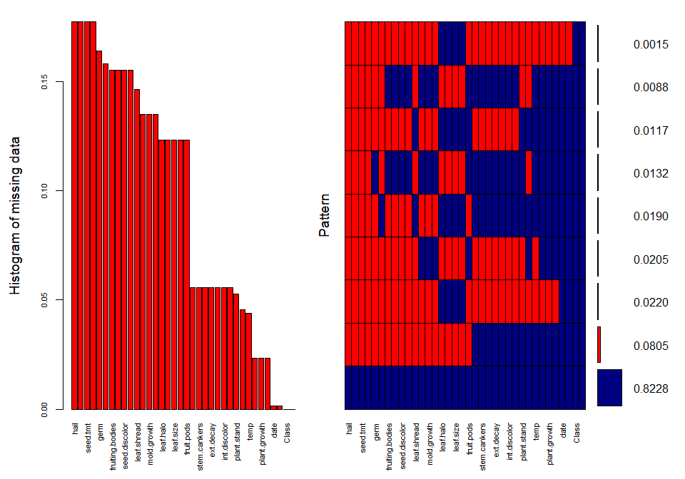

```
##
##  Variables sorted by number of missings:
##         Variable       Count
##             hail 0.177159590
##            sever 0.177159590
##         seed.tmt 0.177159590
##          lodging 0.177159590
##             germ 0.163982430
##        leaf.mild 0.158125915
##  fruiting.bodies 0.155197657
##      fruit.spots 0.155197657
##    seed.discolor 0.155197657
##       shriveling 0.155197657
##      leaf.shread 0.146412884
##             seed 0.134699854
##      mold.growth 0.134699854
##        seed.size 0.134699854
##        leaf.halo 0.122986823
##        leaf.marg 0.122986823
##        leaf.size 0.122986823
##        leaf.malf 0.122986823
##       fruit.pods 0.122986823
##           precip 0.055636896
##     stem.cankers 0.055636896
##    canker.lesion 0.055636896
##        ext.decay 0.055636896
##         mycelium 0.055636896
##     int.discolor 0.055636896
##        sclerotia 0.055636896
##      plant.stand 0.052708638
##            roots 0.045387994
##             temp 0.043923865
##        crop.hist 0.023426061
##     plant.growth 0.023426061
##             stem 0.023426061
##             date 0.001464129
##         area.dam 0.001464129
##            Class 0.000000000
##           leaves 0.000000000
```

```r
ggr_plot <- aggr(Soybean, col=c('navyblue','red'), numbers=TRUE, sortVars=TRUE,
                 labels=names(Soybean), cex.axis=.7, gap=3,
                 ylab=c("Histogram of missing data","Pattern"))
```

For the classes which have missing elements, the count of such missing elements is as follows:

```r
#Number of missing elements
Soybean.incomplete %>%
  summarize_all(list(
    ~ sum(is.na(.)))
    ) %>%
  sort(decreasing = T) %>%
  t() %>%
  kable(caption="Count of missing elements") %>%
  kable_styling(c("bordered","striped"),full_width = F)
```

Count of missing elements

| hail | 121 |
| --- | --- |
| sever | 121 |
| seed.tmt | 121 |
| lodging | 121 |
| germ | 112 |
| leaf.mild | 108 |
| fruiting.bodies | 106 |
| fruit.spots | 106 |
| seed.discolor | 106 |
| shriveling | 106 |
| leaf.shread | 100 |
| seed | 92 |
| mold.growth | 92 |
| seed.size | 92 |
| leaf.halo | 84 |
| leaf.marg | 84 |
| leaf.size | 84 |
| leaf.malf | 84 |
| fruit.pods | 84 |
| precip | 38 |
| stem.cankers | 38 |
| canker.lesion | 38 |
| ext.decay | 38 |
| mycelium | 38 |
| int.discolor | 38 |
| sclerotia | 38 |
| plant.stand | 36 |
| roots | 31 |
| temp | 30 |
| crop.hist | 16 |
| plant.growth | 16 |
| stem | 16 |
| date | 1 |
| area.dam | 1 |
| Class | 0 |
| leaves | 0 |

For the 5 Classes with missing elements, “hail”, “sever”, “seed.tmt” and “lodging” are entirely absent for all cases.

Other elements are missing in accordance with the above table.

### Develop a strategy for handling missing data, either by eliminating predictors or imputation.

#### **Let’s use the MICE package to impute missing values**

MICE: Multivariate Imputation by Chained Equations

```r
library(mice)
comp.data <- mice(Soybean,m=2,maxit=10,meth='pmm',seed=500)
```

```
##
##  * Please inspect the loggedEvents
```

```r
Soybean.imputed = complete(comp.data)
```

#### Any missing data?

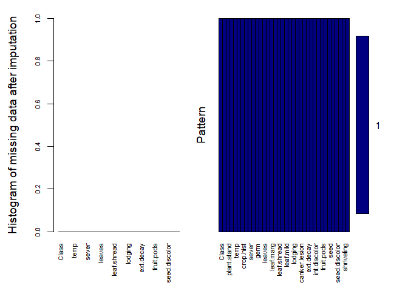

```
##
##  Variables sorted by number of missings:
##         Variable Count
##            Class     0
##             date     0
##      plant.stand     0
##           precip     0
##             temp     0
##             hail     0
##        crop.hist     0
##         area.dam     0
##            sever     0
##         seed.tmt     0
##             germ     0
##     plant.growth     0
##           leaves     0
##        leaf.halo     0
##        leaf.marg     0
##        leaf.size     0
##      leaf.shread     0
##        leaf.malf     0
##        leaf.mild     0
##             stem     0
##          lodging     0
##     stem.cankers     0
##    canker.lesion     0
##  fruiting.bodies     0
##        ext.decay     0
##         mycelium     0
##     int.discolor     0
##        sclerotia     0
##       fruit.pods     0
##      fruit.spots     0
##             seed     0
##      mold.growth     0
##    seed.discolor     0
##        seed.size     0
##       shriveling     0
##            roots     0
```

```r
##### Let's check if there is still any missing data, using VIM::aggr
#library(VIM)
ggr_plot <- aggr(Soybean.imputed,
                 col=c('navyblue','red'),
                 numbers=TRUE,
                 sortVars=TRUE,
                 labels=names(Soybean),
                 cex.axis=.7, gap=3,
                 ylab=c("Histogram of missing data after imputation","Pattern"))
```

**There is no missing data – all the NAs have been assigned imputed values.**